# 14｜分群與表示應用

## 來源與改編界線

- [ageron/handson-mlp / 08_unsupervised_learning.ipynb](https://github.com/ageron/handson-mlp/blob/47eba45aacc85feae51ba7db68dd1ca66cb25e0a/08_unsupervised_learning.ipynb)：K-means、K-means++、inertia／silhouette、影像分割、少量標註與標籤傳播
- [leonjyentub/MachineLearning2025 / 05_Kmeans+SemiSupervisedLearning.ipynb](https://github.com/leonjyentub/MachineLearning2025/blob/3da2cb56b9efd17d7cd34602589f392554b40603/05_Kmeans+SemiSupervisedLearning.ipynb)：代表樣本與標籤傳播
- [leonjyentub/MachineLearning2025 / 05_Cluster_1.py](https://github.com/leonjyentub/MachineLearning2025/blob/3da2cb56b9efd17d7cd34602589f392554b40603/05_Cluster_1.py)：K-means 基本流程

**本課程修改／補充：** 手寫指派／更新兩步並驗算投影片一維 K-means 活動（`[0,1,4,5]`）；驗算輪廓係數手算（`a,b` 兩點）；肘部與輪廓分數一起看；顏色量化改用 scikit-learn 內建 `flower.jpg`（不需下載）；少量標註用 digits，只給 50 個標籤、挑代表樣本、傳播、和「隨機 50 標籤」比較。群編號沒有天然大小與語義。

來源固定至上述 commit；原檔保留於 `../upstream/`，逐檔 SHA-256 見 `../upstream/manifest.json`。Géron 程式依 Apache-2.0 改編，授權原文保留；教師程式保留原作者歸屬。儲存格索引從 0 起算。圖表與數值是本 Notebook 重跑結果，不能直接當成書中成效。

從第一格依序執行；各本可獨立重跑。Python 環境與資料準備見 操作說明。

```python
import numpy as np
import pandas as pd
import matplotlib.pyplot as plt
from mlcourse.common import ROOT, DATA, OUT, SEED, FAST, setup, savefig, report, data_path
setup()
```

```
{'profile': 'fast',
 'seed': 42,
 'data': '/Users/leonjye/Documents/MacProject/MLCourse2026/programs/data'}
```

## 1. K-means 兩步交替與手算驗算

指派：每點到最近中心；更新：中心移到群平均。對應投影片活動：一維資料 `[0,1,4,5]`、初始中心 `[0,4]`。

```python
def assign(x, centers):
    return np.argmin(np.abs(np.asarray(x)[:, None] - np.asarray(centers)[None]), axis=1)
def inertia(x, centers, labels):
    return float(np.sum((np.asarray(x) - np.asarray(centers)[labels]) ** 2))

x1 = np.array([0., 1., 4., 5.])
centers0 = np.array([0., 4.])
lab0 = assign(x1, centers0)
inertia_before = inertia(x1, centers0, lab0)
cen1 = np.array([x1[lab0 == k].mean() for k in range(2)])   # 更新步
lab1 = assign(x1, cen1)
inertia_after = inertia(x1, cen1, lab1)
assert lab0.tolist() == [0, 0, 1, 1] and np.isclose(inertia_before, 2.0)
assert np.allclose(cen1, [0.5, 4.5]) and np.isclose(inertia_after, 1.0)
assert lab1.tolist() == lab0.tolist()      # 指派不再改變 -> 收斂
pd.Series({'initial_labels': lab0.tolist(), 'inertia_before': inertia_before,
           'updated_centers': cen1.tolist(), 'inertia_after': inertia_after})
```

```
initial_labels     [0, 0, 1, 1]
inertia_before              2.0
updated_centers      [0.5, 4.5]
inertia_after               1.0
dtype: object
```

## 2. K-means++、多次初始化與局部解

不同初始化可能收斂到不同局部解（教材圖 8-5）。`init="k-means++"` 讓初始中心分散，`n_init` 取多次最佳（依 inertia）。

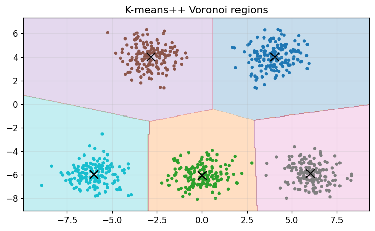

```
single random-init inertia range: 1274.1 - 12677.5  | k-means++ x10 inertia: 1274.1
```

```python
from sklearn.cluster import KMeans
from sklearn.datasets import make_blobs
centers = np.array([[-6, -6], [0, -6], [6, -6], [-3, 4], [4, 4]])
X, y_true = make_blobs(n_samples=800, centers=centers, cluster_std=0.9, random_state=SEED)
runs = []
for seed in range(6):
    km = KMeans(n_clusters=5, init='random', n_init=1, random_state=seed).fit(X)
    runs.append(km.inertia_)
best = KMeans(n_clusters=5, init='k-means++', n_init=10, random_state=SEED).fit(X)
xx, yy = np.meshgrid(np.linspace(X[:, 0].min() - 1, X[:, 0].max() + 1, 300),
                     np.linspace(X[:, 1].min() - 1, X[:, 1].max() + 1, 300))
zz = best.predict(np.c_[xx.ravel(), yy.ravel()]).reshape(xx.shape)
plt.contourf(xx, yy, zz, alpha=.25, cmap='tab10')
plt.scatter(X[:, 0], X[:, 1], c=best.labels_, cmap='tab10', s=10)
plt.scatter(best.cluster_centers_[:, 0], best.cluster_centers_[:, 1], c='k', marker='x', s=120)
plt.title('K-means++ Voronoi regions')
savefig('14_kmeans_voronoi')
print('single random-init inertia range:', round(min(runs), 1), '-', round(max(runs), 1),
      ' | k-means++ x10 inertia:', round(best.inertia_, 1))
```

## 3. 肘部法與輪廓分數，以及輪廓係數手算

肘部看 inertia 改善開始遞減的位置；輪廓分數把群內距離 $a$ 與最近他群距離 $b$ 一起比較，$s=(b-a)/\max(a,b)$。對應投影片活動的兩點。

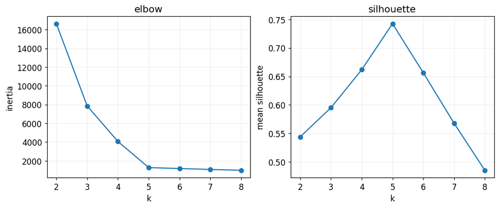

```
silhouette picks k = 5  | hand check: s(a=2,b=5)=0.6, s(a=4,b=3)=-0.25
```

```python
from sklearn.metrics import silhouette_score
def silhouette(a, b):
    return (b - a) / max(a, b)
assert np.isclose(silhouette(2, 5), 0.6) and np.isclose(silhouette(4, 3), -0.25)

ks = range(2, 9)
inertias = [KMeans(n_clusters=k, n_init=10, random_state=SEED).fit(X).inertia_ for k in ks]
sils = [silhouette_score(X, KMeans(n_clusters=k, n_init=10, random_state=SEED).fit_predict(X)) for k in ks]
fig, axes = plt.subplots(1, 2, figsize=(11, 4))
axes[0].plot(list(ks), inertias, 'o-'); axes[0].set(xlabel='k', ylabel='inertia', title='elbow')
axes[1].plot(list(ks), sils, 'o-'); axes[1].set(xlabel='k', ylabel='mean silhouette', title='silhouette')
savefig('14_kmeans_selection')
best_k = list(ks)[int(np.argmax(sils))]
assert best_k == 5                                   # 資料本來 5 群
print('silhouette picks k =', best_k, ' | hand check: s(a=2,b=5)=0.6, s(a=4,b=3)=-0.25')
```

## 4. K-means 的限制：橢圓、密度與群大小差異

K-means 偏好相近大小、球狀、密度相近的群（教材圖 8-10）。縮放前要先想清楚「相似」的定義。

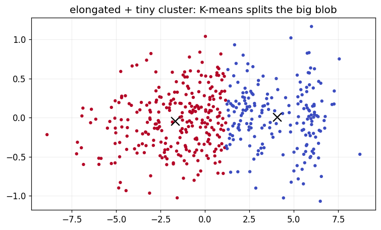

```
fraction of the true tiny cluster kept in one K-means label: 1.0
```

```python
rng = np.random.default_rng(SEED)
blob_a = rng.normal([0, 0], [3.0, 0.4], (400, 2))
blob_b = rng.normal([6, 0], [0.4, 0.4], (60, 2))
Xe = np.vstack([blob_a, blob_b])
km = KMeans(n_clusters=2, n_init=10, random_state=SEED).fit(Xe)
plt.scatter(Xe[:, 0], Xe[:, 1], c=km.labels_, cmap='coolwarm', s=10)
plt.scatter(km.cluster_centers_[:, 0], km.cluster_centers_[:, 1], c='k', marker='x', s=120)
plt.title('elongated + tiny cluster: K-means splits the big blob')
savefig('14_kmeans_limits')
small_recovered = np.bincount(km.labels_[-60:]).max() / 60
print('fraction of the true tiny cluster kept in one K-means label:', round(small_recovered, 2))
```

## 5. 顏色量化：K-means 當作影像分割

把每個像素當成 RGB 三維點，用 K 個群中心取代所有像素顏色（教材圖 8-11）。使用 scikit-learn 內建 `flower.jpg`。

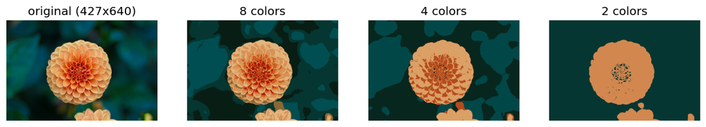

```
unique colors: original 62941 -> quantized to 8
```

```python
from sklearn.datasets import load_sample_image
image = load_sample_image('flower.jpg')
pixels = (image / 255.0).reshape(-1, 3)
fig, axes = plt.subplots(1, 4, figsize=(14, 4))
axes[0].imshow(image); axes[0].set_title(f'original ({image.shape[0]}x{image.shape[1]})'); axes[0].axis('off')
for ax, n in zip(axes[1:], [8, 4, 2]):
    km = KMeans(n_clusters=n, n_init=3, random_state=SEED).fit(pixels[::5])   # 抽樣加速
    seg = km.cluster_centers_[km.predict(pixels)].reshape(image.shape)
    ax.imshow(seg); ax.set_title(f'{n} colors'); ax.axis('off')
savefig('14_color_quantization')
km8 = KMeans(n_clusters=8, n_init=3, random_state=SEED).fit(pixels[::5])
print('unique colors: original', len(np.unique(pixels, axis=0)), '-> quantized to', km8.n_clusters)
```

## 6. 少量標註：先標代表樣本，再傳播

digits 只給 50 個標籤預算。比較「隨機 50 個」與「每群挑最接近中心的一張」，再把群中心標籤傳播給整群（教材圖 8-12）。

```python
from sklearn.datasets import load_digits
from sklearn.model_selection import train_test_split
from sklearn.linear_model import LogisticRegression
from sklearn.preprocessing import StandardScaler
from sklearn.pipeline import make_pipeline
digits = load_digits()
Xtr, Xte, ytr, yte = train_test_split(digits.data, digits.target, test_size=.3, stratify=digits.target, random_state=SEED)
k = 50
km = KMeans(n_clusters=k, n_init=10, random_state=SEED).fit(Xtr)
rep_idx = np.argmin(km.transform(Xtr), axis=0)          # 每群最接近中心的樣本
rep_labels = ytr[rep_idx]

def score(mask_or_idx, y_used):
    clf = make_pipeline(StandardScaler(), LogisticRegression(max_iter=2000))
    clf.fit(Xtr[mask_or_idx], y_used)
    return clf.score(Xte, yte)

rng = np.random.default_rng(SEED)
rand_idx = rng.choice(len(Xtr), k, replace=False)
acc_random = score(rand_idx, ytr[rand_idx])
acc_representative = score(rep_idx, rep_labels)
propagated = rep_labels[km.labels_]                     # 把代表標籤傳播給整群
acc_propagated = score(np.arange(len(Xtr)), propagated)
report('clustering', {'kmeans_1d': {'inertia_before': 2.0, 'inertia_after': 1.0},
       'silhouette_best_k': int(best_k), 'label_budget': k,
       'accuracy_random_labels': acc_random, 'accuracy_representative_labels': acc_representative,
       'accuracy_after_propagation': acc_propagated})
assert acc_representative >= acc_random - 0.02
pd.Series({'random_50_labels': acc_random, 'representative_50_labels': acc_representative,
           'propagate_to_full_train': acc_propagated})
```

```
random_50_labels            0.837037
representative_50_labels    0.877778
propagate_to_full_train     0.933333
dtype: float64
```

## 練習與參考答案

- 群編號 `2` 比 `1` 大嗎？**否，編號沒有大小或固定語義。**
- 平均輪廓分數很高就代表分群成功嗎？**否，要看每群分布與少數群的負值，以及業務意義。**
- 一群只有一個樣本怎麼算輪廓？**沒有同群其他點可平均，通常設 $s=0$。**
- 顏色量化只用 RGB，缺了什麼？**空間位置與語義；相鄰但不同物件的像素可能同群。**